# IS606 - Final Meetup

May 12, 2017

## Final Exam

- Will be available by May 15th (I will send an announcement if available sooner).
- Due by 5pm on May 20th.
- You may use your book and course materials.
- There are two parts:
  1. Part one has some conceptual questions.
  2. Part two has a small data set to analyze with R, then answer some interpretation questions.

## The Logistic Function

\[ \sigma \left( t \right) =\frac { { e }^{ t } }{ { e }^{ t }+1 } =\frac { 1 }{ 1+{ e }^{ -t } } \]

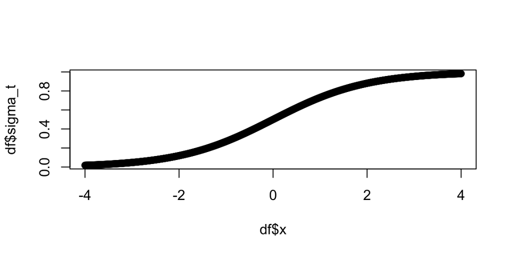

```r
logistic <- function(t) { return(1 / (1 + exp(-t))) }
df <- data.frame(x=seq(-4, 4, by=0.01))
df$sigma_t <- logistic(df$x)
plot(df$x, df$sigma_t)
```

## *t* as a Linear Function

\[ t = \beta_0 + \beta_1 x \]

The logistic function can now be rewritten as

\[ F\left( x \right) =\frac { 1 }{ 1+{ e }^{ -\left( { \beta }_{ 0 }+\beta _{ 1 }x \right) } } \]

## Example: Hours Studying Predicting Passing

```r
study <- data.frame(
    Hours=c(0.50,0.75,1.00,1.25,1.50,1.75,1.75,2.00,2.25,2.50,2.75,3.00,3.25,3.50,4.00,4.25,4.50,4.75,5.00,5.50),
    Pass=c(0,0,0,0,0,0,1,0,1,0,1,0,1,0,1,1,1,1,1,1)
)
lr.out <- glm(Pass ~ Hours, data=study, family=binomial)
lr.out
```

```
##
## Call:  glm(formula = Pass ~ Hours, family = binomial, data = study)
##
## Coefficients:
## (Intercept)        Hours
##      -4.078        1.505
##
## Degrees of Freedom: 19 Total (i.e. Null);  18 Residual
## Null Deviance:       27.73
## Residual Deviance: 16.06     AIC: 20.06
```

## Fitted Values

```r
study[1,]
```

```
##   Hours Pass
## 1   0.5    0
```

```r
logistic <- function(x, b0, b1) {
    return(1 / (1 + exp(-1 * (b0 + b1 * x)) ))
}
logistic(.5, b0=-4.078, b1=1.505)
```

```
## [1] 0.03470667
```

Of course, the `fitted` function will do the same:

```r
study$fitted <- fitted(lr.out)
study[1,]
```

```
##   Hours Pass     fitted
## 1   0.5    0 0.03471034
```

## Plotting the Results

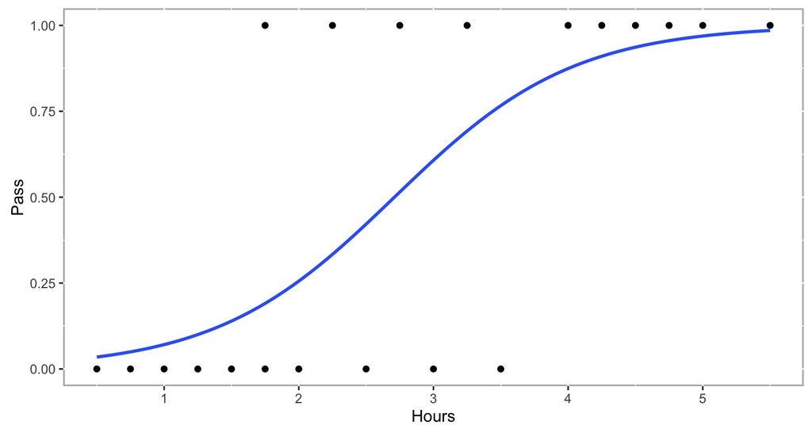

```r
binomial_smooth <- function(...) {
    geom_smooth(method = "glm", method.args = list(family = "binomial"), ...)
}

ggplot(study, aes(x=Hours, y=Pass)) + geom_point() +
    binomial_smooth(se=FALSE)
```

## Residuals

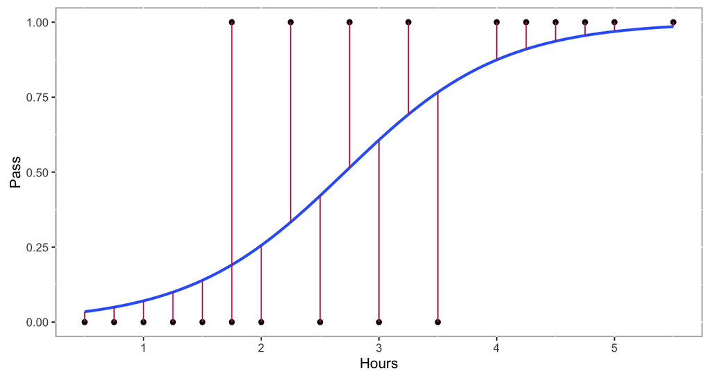

```r
study$residuals <- study$Pass - study$fitted

ggplot(study, aes(x=Hours, y=Pass)) + geom_point() +
    binomial_smooth(se=FALSE) +
    geom_segment(aes(xend=Hours, yend=fitted), color='maroon')
```

## My Work

My research interest is in propensity score methods. Propensity score analysis (PSA) is a quasi-experimental design used to estimate causality from observational studies. It is generally conducted in two phases:

1. Estimate propensity scores (i.e. probability of being in the treatment) using the observed covariates.
   1. Check balance
   2. Re-estimate propensity scores
2. Estimate effect sizes using typical group differences (e.g. t-tests)

Areas I have worked on:

- Multilevel PSA (see [`multilevelPSA`](http://jason.bryer.org/multilevelPSA) R package)
- Matching with non-binary treatments (see [`TriMatch`](http://jason.bryer.org/TriMatch) R package)
- Bootstrapping PSA (see [`PSAboot`](http://jason.bryer.org/PSAboot) R package)

## Thank You

This has been a great semester. Please don't hesitate to reach out:

- Email: jason.bryer@gmail.com
- Github: http://github.com/jbryer
- Blog: http://bryer.org
- [LinkedIn](https://www.linkedin.com/profile/view?id=AAMAAATGdnoBOWXg80yqna6fSkgnZdabZP7Ck9w&trk=hp-identity-name)
- Twitter: [@jbryer](https://twitter.com/jbryer) (don't Tweet very much though)